# Part II - Some Prosper Borrowers' Demographics, including Credit Rating and their Effects on Investor Behaviour.

## by Chimmuanya Mogbo

## Investigation Overview

> In this presentation, I intend to highlight some Prosper Loan demographics, especially those of their Borrower Partners. I also intend to briefly take a look at their possible effects on investor behaviour

## Dataset Overview

> This data set contains information regarding 113,937 loans with 81 variables on each loan from Prosper, an online peer-to-peer lending marketplace based in the United States. It contains vital information on their identity, credit rating, social status, the type and duration of loans they applied for, and the status of their loan. It also contains information on the status of previous loans, and how many people have invested in their loans. Other important features include their employment status, occupation, salary, and Borrower state. I am most interested in how these variables influenced investor behaviour and client ability to secure and to pay off their loans.

## Current and Completed Loans make up 83.1% of all Prosper loans.

1. The majority of Prosper Loans -56,576 loans are current loans. This represents 49.7% of all their loans.
2. A close second subcategory of Prosper loans have been completely repaid (38,074), which represents 33.4% of all their loans .

   > Together with the current loans, they both make up 83.1% of all Prosper loans.
3. A distant third subcategory of loans have been charged off (written off as losses) - a whopping 10.5%. This is apart from the 4.4% of loans that have been defaulted on.

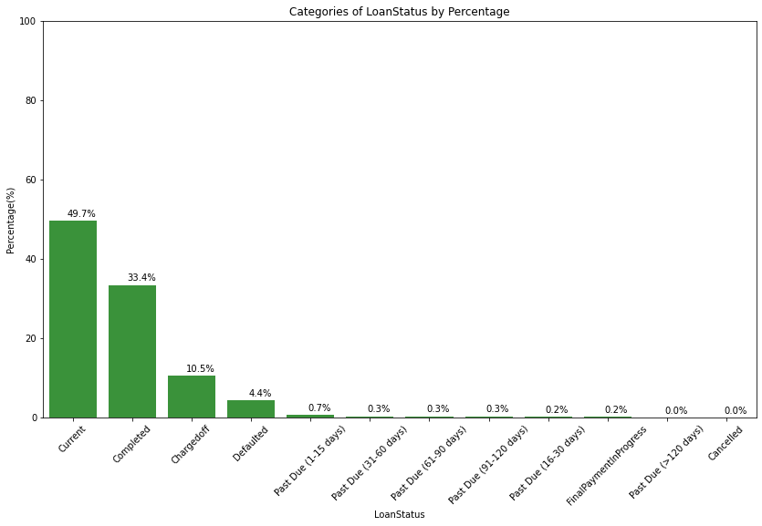

## Over 80% of all Prosper Loans debtors are earning or earned more than USD25,000 per year.

#### It would seem that Prosper Loan investors were more likely to lend to creditors that are or were in some form of employment.

1. Over 80% of all Prosper Loans debtors are earning or earned more than \$25,000 per year.
- In the same vein, over 80\% of this same population were or are employed in some way.
- A vast majority of indebted clients (59.1\%) were or are employed. Another 23\% have or had fulltime jobs.

  > It would seem that Prosper Loan investors were more likely to lend to creditors that are or were in some form of employment. Clearly, investors preferred capital security to risk, as is almost always the case everywhere.

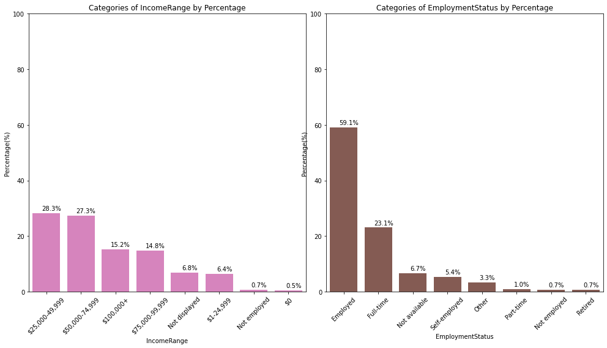

## Prosper Loan Borrowers generally have or had a high credit rating.

#### And Home Owners Benefitted more!

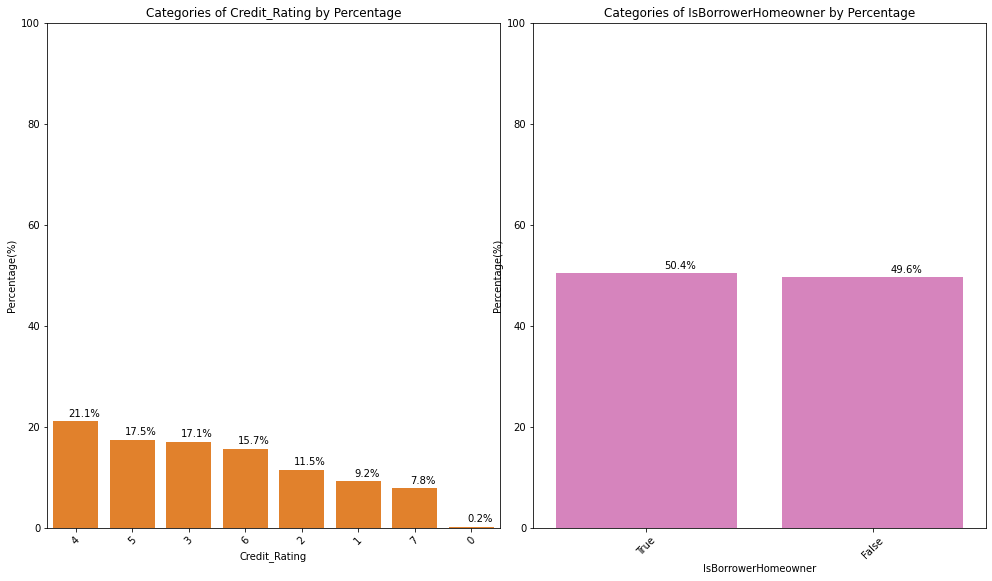

## Prosper Loans Interest Rates Tend to be Higher than Lower.

#### And what is it with 32% per annum!?

1. Both the Borrower Interest Rate and Annual Percentage Rate are skewed to the right.
- Majority of the interest rates fell between 10% (0.1) per annum and just above 30% per annum

  > Interestingly, there is a huge spike in the number of loans charged at an interest rate of just about 32% (about 5000 loans). This spike also corresponded with a spike in the number of loans charged at an Annual Percentage Rate of about 35% per annum (about 6000 loans).

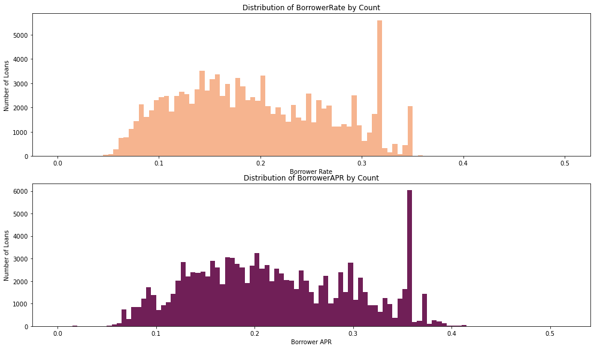

## ... And they are Quite Profitable!

- Prosper loans are quite profitable, with most of them having a profitabilty of between 10% and 25%.
- A large number of loans (about 5000+) have a yield of about 31% in particular.

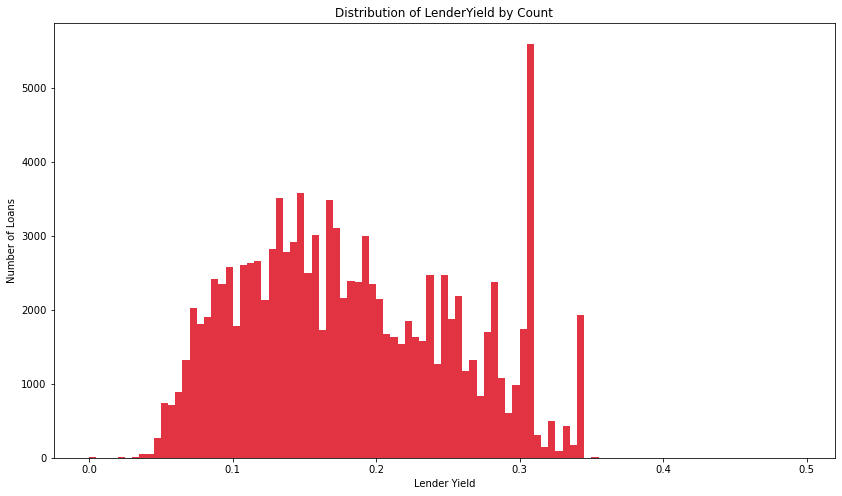

## The Peace Garden State is the Best, North Dakota!

#### What is it with Maine, ... and DC?

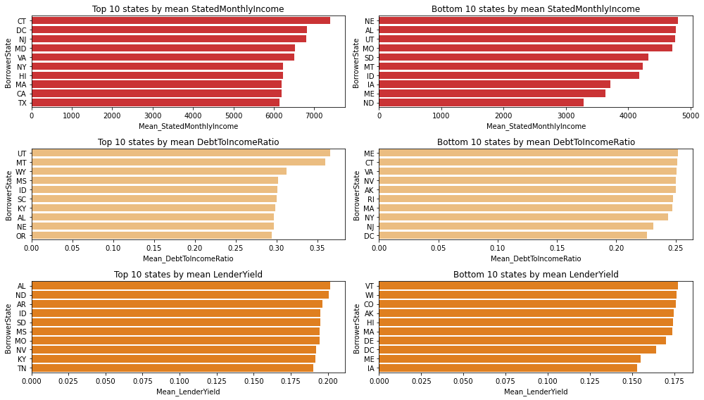

## Fix your Credit Rating Borrowers

#### ... And maybe Enjoy Lower Rates and More Investors!

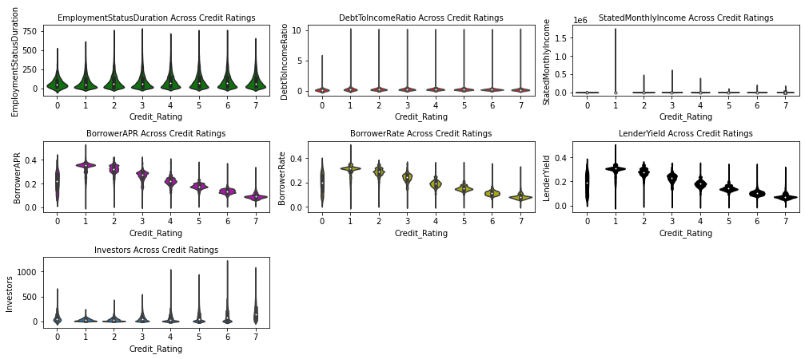

## Tried and Failed to get Loans?

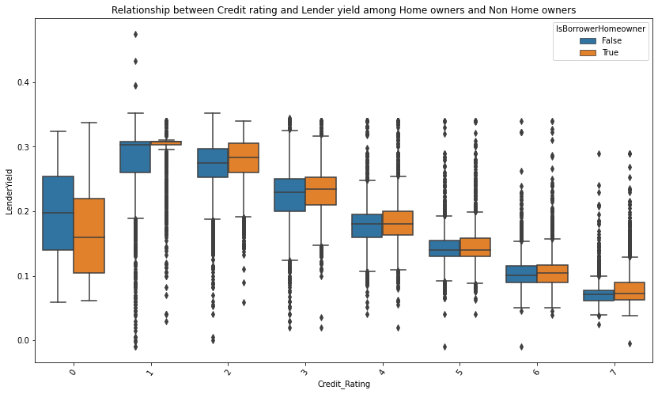